# 04 – Win and Playoff Modeling

Model how pace and efficiency relate to win percentage and playoff probability.

## Goals

- Load team-season aggregates and engineer targets for win percentage and playoff odds.
- Train baseline models (logistic and linear) using pace/efficiency/shot profile features.
- Check feature importances and calibration by era for interpretability.

```python
from pathlib import Path
import sys

PROJECT_ROOT = Path.cwd().resolve()
if PROJECT_ROOT.name == 'notebooks':
    PROJECT_ROOT = PROJECT_ROOT.parent
if str(PROJECT_ROOT) not in sys.path:
    sys.path.insert(0, str(PROJECT_ROOT))

import pandas as pd

from src.pipeline.season_summary import generate_team_season_summary
from src.data_ingest import NBADataIngestor
from sklearn.model_selection import train_test_split
from sklearn.preprocessing import StandardScaler
from sklearn.pipeline import make_pipeline
from sklearn.linear_model import LogisticRegression, LinearRegression, Ridge
from sklearn.tree import DecisionTreeClassifier, DecisionTreeRegressor
from sklearn.ensemble import RandomForestClassifier, RandomForestRegressor, GradientBoostingClassifier, GradientBoostingRegressor
from sklearn.neighbors import KNeighborsClassifier, KNeighborsRegressor
from sklearn.svm import SVC
from sklearn.calibration import calibration_curve
from sklearn.metrics import (
    accuracy_score,
    f1_score,
    roc_auc_score,
    classification_report,
    confusion_matrix,
    mean_squared_error,
    mean_absolute_error,
    r2_score,
    brier_score_loss,
)
import numpy as np
import matplotlib.pyplot as plt
import seaborn as sns
```

```python
# Load regular-season team summaries (use cached CSV when available).
summary_path = Path("data/processed/team_season_regular.csv")
if summary_path.exists():
    summary = pd.read_csv(summary_path)
else:
    ingestor = NBADataIngestor()
    summary = generate_team_season_summary(ingestor, regular_season_only=True, save=False)

summary.head()
```

|  | TEAM_ID | SEASON_YEAR | IS_PLAYOFFS | PACE | OFF_EFF_PER_100 | DEF_EFF_PER_100 | THREE_POINT_RATE | AST_TOV_RATIO | TOTAL_EST_POSSESSIONS | WIN_PCT | GAMES_PLAYED | ERA_KEY | ERA_LABEL | ERA_START_YEAR | ERA_END_YEAR |
| --- | --- | --- | --- | --- | --- | --- | --- | --- | --- | --- | --- | --- | --- | --- | --- |
| 0 | 12304 | 2006 | False | 75.898936 | 137.024318 | 130.436611 | 0.303797 | NaN | 75.898936 | 1.0 | 1 | pace_and_space_rise | Pace-and-Space Rise | 2005 | 2013 |
| 1 | 12321 | 2012 | False | 88.874291 | 109.142925 | 102.391816 | 0.269231 | 1.0 | 88.874291 | 1.0 | 1 | pace_and_space_rise | Pace-and-Space Rise | 2005 | 2013 |
| 2 | 12321 | 2013 | False | 85.440470 | 95.973255 | 111.188527 | 0.411765 | 0.8125 | 85.440470 | 0.0 | 1 | pace_and_space_rise | Pace-and-Space Rise | 2005 | 2013 |
| 3 | 1610610024 | 1947 | False | NaN | NaN | NaN | NaN | NaN | NaN | 0.0 | 1 | pre_shot_clock | Early BAA/NBL | 1946 | 1953 |
| 4 | 1610610029 | 1948 | False | NaN | NaN | NaN | NaN | NaN | NaN | 1.0 | 1 | pre_shot_clock | Early BAA/NBL | 1946 | 1953 |

```python
# Basic cleaning and feature selection.
feature_cols = [
    "PACE",
    "OFF_EFF_PER_100",
    "DEF_EFF_PER_100",
    "THREE_POINT_RATE",
    "AST_TOV_RATIO",
]
summary = summary.dropna(subset=feature_cols + ["WIN_PCT"])

# Binary target: top quartile win percentage as proxy for playoff-level success.
win_pct_threshold = summary["WIN_PCT"].quantile(0.75)
summary["TOP_QUARTILE_WIN"] = (summary["WIN_PCT"] >= win_pct_threshold).astype(int)

X = summary[feature_cols]
y_class = summary["TOP_QUARTILE_WIN"]
y_reg = summary["WIN_PCT"]

summary[["WIN_PCT", "TOP_QUARTILE_WIN"] + feature_cols].describe(include="all")
```

|  | WIN_PCT | TOP_QUARTILE_WIN | PACE | OFF_EFF_PER_100 | DEF_EFF_PER_100 | THREE_POINT_RATE | AST_TOV_RATIO |
| --- | --- | --- | --- | --- | --- | --- | --- |
| count | 257.000000 | 257.000000 | 257.000000 | 257.000000 | 257.000000 | 257.000000 | 257.0 |
| unique | NaN | NaN | NaN | NaN | NaN | NaN | 179.0 |
| top | NaN | NaN | NaN | NaN | NaN | NaN | 1.0 |
| freq | NaN | NaN | NaN | NaN | NaN | NaN | 11.0 |
| mean | 0.492218 | 0.482490 | 103.499465 | 108.276925 | 108.427557 | 0.222597 | NaN |
| std | 0.496017 | 0.500668 | 14.095664 | 12.973109 | 12.992439 | 0.138811 | NaN |
| min | 0.000000 | 0.000000 | 81.655197 | 70.459581 | 70.459581 | 0.000000 | NaN |
| 25% | 0.000000 | 0.000000 | 93.448469 | 98.449981 | 98.779271 | 0.121212 | NaN |
| 50% | 0.500000 | 0.000000 | 99.193208 | 108.041123 | 107.574059 | 0.206612 | NaN |
| 75% | 1.000000 | 1.000000 | 113.410242 | 117.182585 | 117.182585 | 0.291139 | NaN |
| max | 1.000000 | 1.000000 | 145.525115 | 146.447551 | 146.447551 | 0.666667 | NaN |

```
ROC AUC: 0.9881481481481482
              precision    recall  f1-score   support

           0       0.96      0.96      0.96        27
           1       0.96      0.96      0.96        25

    accuracy                           0.96        52
   macro avg       0.96      0.96      0.96        52
weighted avg       0.96      0.96      0.96        52
```

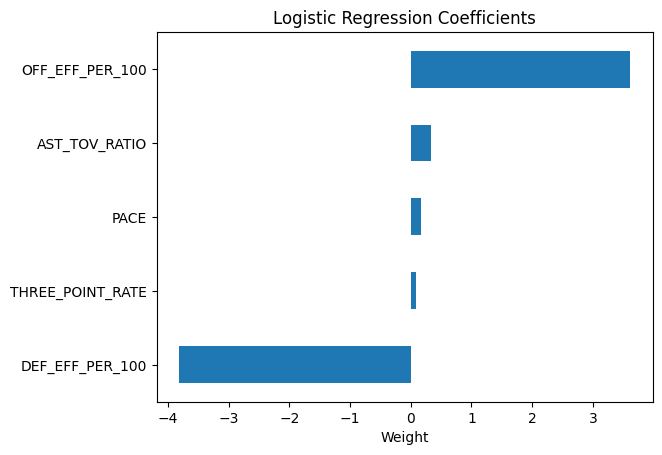

```python
# Classification: logistic regression on standardized features.
X_train, X_test, y_train, y_test = train_test_split(X, y_class, test_size=0.2, random_state=42, stratify=y_class)

log_clf = make_pipeline(
    StandardScaler(),
    LogisticRegression(max_iter=500, penalty="l2", solver="lbfgs"),
)
log_clf.fit(X_train, y_train)

probs = log_clf.predict_proba(X_test)[:, 1]
preds = (probs >= 0.5).astype(int)

print("ROC AUC:", roc_auc_score(y_test, probs))
print(classification_report(y_test, preds))

# Extract feature weights for interpretation.
coef = log_clf.named_steps["logisticregression"].coef_.ravel()
importance = pd.Series(coef, index=feature_cols).sort_values()
importance.plot(kind="barh", title="Logistic Regression Coefficients")
plt.xlabel("Weight")
plt.show()
```

```
RMSE on full sample: 0.2981
```

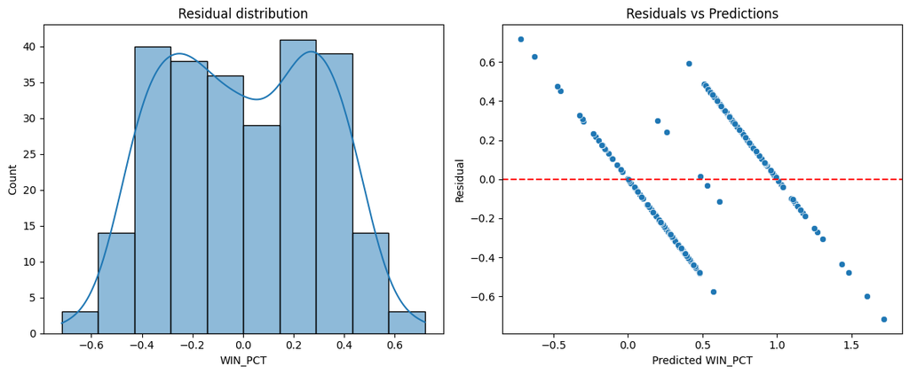

```python
# Regression: predict win percentage directly.
reg_model = make_pipeline(StandardScaler(), LinearRegression())
reg_model.fit(X, y_reg)
pred_win_pct = reg_model.predict(X)

rmse = np.sqrt(mean_squared_error(y_reg, pred_win_pct))
print(f"RMSE on full sample: {rmse:.4f}")

residuals = y_reg - pred_win_pct
fig, ax = plt.subplots(1, 2, figsize=(12, 5))
sns.histplot(residuals, kde=True, ax=ax[0])
ax[0].set_title("Residual distribution")
sns.scatterplot(x=pred_win_pct, y=residuals, ax=ax[1])
ax[1].axhline(0, color="red", linestyle="--")
ax[1].set_xlabel("Predicted WIN_PCT")
ax[1].set_ylabel("Residual")
ax[1].set_title("Residuals vs Predictions")
plt.tight_layout()
plt.show()
```

### Model zoo and report-ready metrics

Compare multiple classifiers on the top-quartile playoff proxy and capture headline metrics for the report.

```python
# Classification model zoo.
class_models = {
    "LogReg": make_pipeline(StandardScaler(), LogisticRegression(max_iter=600, penalty="l2", solver="lbfgs")),
    "SVC-linear": make_pipeline(StandardScaler(), SVC(kernel="linear", probability=True, random_state=42)),
    "RandomForest": RandomForestClassifier(n_estimators=300, max_depth=None, min_samples_leaf=2, random_state=42),
    "GradBoost": GradientBoostingClassifier(random_state=42),
    "DecisionTree": DecisionTreeClassifier(max_depth=6, random_state=42),
    "KNN": make_pipeline(StandardScaler(), KNeighborsClassifier(n_neighbors=15)),
}

class_records = []
for name, model in class_models.items():
    model.fit(X_train, y_train)
    probas = model.predict_proba(X_test)[:, 1]
    preds = (probas >= 0.5).astype(int)
    class_records.append(
        {
            "model": name,
            "roc_auc": roc_auc_score(y_test, probas),
            "accuracy": accuracy_score(y_test, preds),
            "f1": f1_score(y_test, preds),
        }
    )

class_df = pd.DataFrame(class_records).sort_values("roc_auc", ascending=False)
class_df
```

|  | model | roc_auc | accuracy | f1 |
| --- | --- | --- | --- | --- |
| 5 | KNN | 0.991111 | 0.923077 | 0.913043 |
| 0 | LogReg | 0.988148 | 0.961538 | 0.960000 |
| 1 | SVC-linear | 0.988148 | 0.961538 | 0.960000 |
| 3 | GradBoost | 0.965926 | 0.865385 | 0.862745 |
| 2 | RandomForest | 0.964444 | 0.865385 | 0.867925 |
| 4 | DecisionTree | 0.885926 | 0.884615 | 0.884615 |

```python
# Confusion matrix for the top-performing classifier.
best_model_name = class_df.iloc[0]["model"]
best_model = class_models[best_model_name]
best_preds = best_model.predict(X_test)
cm = confusion_matrix(y_test, best_preds)
print(f"Best classifier: {best_model_name}")
print(cm)
```

```
Best classifier: KNN
[[27  0]
 [ 4 21]]
```

### Calibration (regular-season best classifier)

Reliability curve and Brier score for the top model to report probability quality.

```
Brier score (lower is better): 0.1014
```

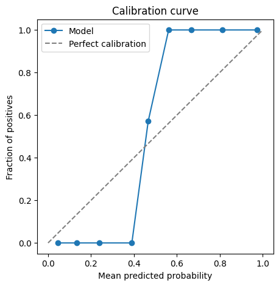

```python
probs_best = best_model.predict_proba(X_test)[:, 1]
brier = brier_score_loss(y_test, probs_best)
prob_true, prob_pred = calibration_curve(y_test, probs_best, n_bins=10, strategy="quantile")

print(f"Brier score (lower is better): {brier:.4f}")
plt.figure(figsize=(5, 5))
plt.plot(prob_pred, prob_true, marker="o", label="Model")
plt.plot([0, 1], [0, 1], linestyle="--", color="gray", label="Perfect calibration")
plt.xlabel("Mean predicted probability")
plt.ylabel("Fraction of positives")
plt.title("Calibration curve")
plt.legend()
plt.show()
```

### Regression baselines

Benchmark RMSE/MAE/R² for predicting win percentage.

```python
reg_models = {
    "Linear": make_pipeline(StandardScaler(), LinearRegression()),
    "Ridge": make_pipeline(StandardScaler(), Ridge(alpha=1.0)),
    "RandomForest": RandomForestRegressor(n_estimators=400, random_state=42, min_samples_leaf=2),
    "GradBoost": GradientBoostingRegressor(random_state=42),
    "DecisionTree": DecisionTreeRegressor(max_depth=8, random_state=42),
    "KNN": make_pipeline(StandardScaler(), KNeighborsRegressor(n_neighbors=15)),
}

reg_records = []
for name, model in reg_models.items():
    model.fit(X, y_reg)
    preds = model.predict(X)
    reg_records.append(
        {
            "model": name,
            "rmse": np.sqrt(mean_squared_error(y_reg, preds)),
            "mae": mean_absolute_error(y_reg, preds),
            "r2": r2_score(y_reg, preds),
        }
    )

reg_df = pd.DataFrame(reg_records).sort_values("rmse")
reg_df
```

|  | model | rmse | mae | r2 |
| --- | --- | --- | --- | --- |
| 4 | DecisionTree | 0.000000 | 0.000000 | 1.000000 |
| 3 | GradBoost | 0.080347 | 0.053624 | 0.973659 |
| 2 | RandomForest | 0.112760 | 0.065117 | 0.948118 |
| 5 | KNN | 0.287985 | 0.226848 | 0.661592 |
| 0 | Linear | 0.298141 | 0.258973 | 0.637305 |
| 1 | Ridge | 0.298152 | 0.259185 | 0.637277 |

### Feature ablations

Remove one feature at a time to quantify its contribution to classification AUC and regression RMSE.

```python
def evaluate_ablation(drop_cols):
    cols = [c for c in feature_cols if c not in drop_cols]
    X_sub = summary[cols].dropna()
    y_class_sub = summary.loc[X_sub.index, "TOP_QUARTILE_WIN"]
    y_reg_sub = summary.loc[X_sub.index, "WIN_PCT"]
    X_train_sub, X_test_sub, y_train_sub, y_test_sub = train_test_split(
        X_sub, y_class_sub, test_size=0.2, random_state=42, stratify=y_class_sub
    )
    clf = make_pipeline(StandardScaler(), LogisticRegression(max_iter=600))
    clf.fit(X_train_sub, y_train_sub)
    probas = clf.predict_proba(X_test_sub)[:, 1]
    auc = roc_auc_score(y_test_sub, probas)

    reg = make_pipeline(StandardScaler(), LinearRegression())
    reg.fit(X_sub, y_reg_sub)
    rmse = np.sqrt(mean_squared_error(y_reg_sub, reg.predict(X_sub)))
    return auc, rmse

ablation_records = []
for col in feature_cols:
    auc, rmse = evaluate_ablation([col])
    ablation_records.append({"dropped": col, "auc_no_feat": auc, "rmse_no_feat": rmse})

ablation_df = pd.DataFrame(ablation_records).sort_values("auc_no_feat", ascending=False)
ablation_df
```

|  | dropped | auc_no_feat | rmse_no_feat |
| --- | --- | --- | --- |
| 0 | PACE | 0.991111 | 0.298141 |
| 3 | THREE_POINT_RATE | 0.989630 | 0.298185 |
| 4 | AST_TOV_RATIO | 0.985185 | 0.298493 |
| 1 | OFF_EFF_PER_100 | 0.891852 | 0.382052 |
| 2 | DEF_EFF_PER_100 | 0.782222 | 0.435651 |

These tables can drop straight into the LaTeX report (classification AUC/accuracy/F1, regression RMSE/MAE/R², and ablation deltas).

### Playoff-only evaluation

```python
playoff_path = Path("data/processed/team_season_playoffs.csv")
if playoff_path.exists():
    playoff = pd.read_csv(playoff_path)
else:
    ingestor = NBADataIngestor()
    playoff = generate_team_season_summary(ingestor, playoffs_only=True, save=False)

playoff = playoff.dropna(subset=feature_cols + ["WIN_PCT"])
if len(playoff) < 20:
    print(f"Playoff sample too small for robust eval (n={len(playoff)}).")
else:
    playoff_threshold = playoff["WIN_PCT"].quantile(0.75)
    playoff["TOP_QUARTILE_WIN"] = (playoff["WIN_PCT"] >= playoff_threshold).astype(int)
    X_po = playoff[feature_cols]
    y_po = playoff["TOP_QUARTILE_WIN"]
    X_train_po, X_test_po, y_train_po, y_test_po = train_test_split(
        X_po, y_po, test_size=0.2, random_state=42, stratify=y_po
    )

    po_records = []
    for name, model in class_models.items():
        model.fit(X_train_po, y_train_po)
        probas_po = model.predict_proba(X_test_po)[:, 1]
        preds_po = (probas_po >= 0.5).astype(int)
        po_records.append(
            {
                "model": name,
                "roc_auc": roc_auc_score(y_test_po, probas_po),
                "accuracy": accuracy_score(y_test_po, preds_po),
                "f1": f1_score(y_test_po, preds_po),
            }
        )
    playoff_df = pd.DataFrame(po_records).sort_values("roc_auc", ascending=False)
    playoff_df
```

[output not shown]

## Next Steps

- Add era-stratified splits or time-based CV to test stability of coefficients.
- Calibrate classifiers (Platt/Isotonic) and compare lift vs uncalibrated.
- Add playoff-only split and compare deltas against regular-season models.